# Blood Cell Atlas Construction

A comprehensive blood cell atlas is constructed from 10X FLEX single-cell RNA-seq data across a time course (0h, 2h, 4h, 6h, 8h, 24h) with multiple donors. DRVI is used to learn latent representations while regressing out technical batch effects, enabling identification of distinct cell type populations.

**Pipeline Overview:**

- Load raw 10X data and extract metadata from cell barcodes
- Perform quality control and adaptive doublet detection
- Train DRVI model (16 latents) to capture cell type-level variation
- Identify and validate cell type clusters using canonical markers
- Export annotated atlas for downstream analysis

## Setup and Environment

Google Drive is mounted and required packages are installed for single-cell analysis.

```python
from google.colab import drive
drive.mount('/content/drive')
```

```python
!pip install scikit-misc drvi-py 'scanpy[leiden]'
```

```python
!pip uninstall torchvision
```

```python
!pip install --upgrade scanpy
```

```python
import re
import drvi
import scvi
import numpy
import torch
import scanpy
import pandas
import warnings
import seaborn as sns
import statsmodels.api as sm
import matplotlib.pyplot as plt
import matplotlib.ticker as mtick
from sklearn.mixture import GaussianMixture
from statsmodels.formula.api import mixedlm, ols
from statsmodels.stats.multitest import multipletests
```

```python
# Set random seeds for reproducibility
scvi.settings.seed = 0
warnings.filterwarnings('ignore')
torch.set_float32_matmul_precision('high')
```

```
INFO: Seed set to 0
INFO:lightning.fabric.utilities.seed:Seed set to 0
```

## Data Loading and Metadata Extraction

Raw 10X count data is loaded and cell barcodes are parsed to extract metadata. Barcode format follows the pattern: `donor_tissue_timepoint.barcode`.

```python
# Define path to raw 10X data
dataset = '/content/drive/My Drive/neutrophills_singlecell/raw/'
```

```python
# Load raw 10X count matrix
adata = scanpy.read_10x_mtx(dataset)
```

## Quality Control and Doublet Detection

Scrublet is used to compute doublet scores per batch, followed by Gaussian Mixture Model classification to adaptively identify doublets rather than using a fixed threshold.

```python
# Parse metadata from cell barcodes (donor, tissue, time, batch) and calculate QC metrics
obs_idx = adata.obs_names.astype(str)

split_df = obs_idx.to_series(index=adata.obs_names).str.extract(r'^(?P<prefix>[^.]+)\.(?P<barcode>.+)$')

meta_df = split_df['prefix'].str.extract(
    r'^(?P<donor>[^_]+)_(?P<tissue>[^_]+)_(?P<time_point>[^_.]+)$'
)

adata.obs['donor'] = meta_df['donor']
adata.obs['tissue'] = meta_df['tissue']
adata.obs['barcode'] = split_df['barcode']
adata.obs['time_point'] = meta_df['time_point']

ordered_time = ['0h', '2h', '4h', '6h', '8h', '24h']
adata.obs['time_point'] = pandas.Categorical(adata.obs['time_point'], categories=ordered_time, ordered=True)


for col in ['donor', 'tissue', 'time_point']:
    adata.obs[col] = adata.obs[col].astype('category')

adata.obs['capture_batch'] = adata.obs['donor'].astype(str) + '_' + adata.obs['time_point'].astype(str)
adata.obs['capture_batch'] = adata.obs['capture_batch'].astype('category')

adata.var['mito'] = adata.var_names.str.startswith('MT-')
scanpy.pp.calculate_qc_metrics(adata, qc_vars=['mito'], inplace=True, log1p=True)


batch_key = 'capture_batch'
```

```python
# Run Scrublet doublet detection per batch
avg_doublet_rate = (adata.obs[batch_key].value_counts() * 8e-6).mean()

scanpy.pp.scrublet(adata, expected_doublet_rate=avg_doublet_rate, batch_key=batch_key)
```

## Cell and Gene Filtering

Genes are filtered to remove mitochondrial, ribosomal, and non-coding transcripts. Cells are filtered based on QC thresholds from the original paper: 200-4000 genes, 200-15000 counts, and <1% mitochondrial content. Predicted doublets are removed.

```python
# Use GMM to classify doublets adaptively
scores = adata.obs['doublet_score'].values.reshape(-1, 1) # type: ignore

gmm = GaussianMixture(n_components=2, random_state=0)
gmm.fit(scores)

labels = gmm.predict(scores)

cluster_means = {i: scores[labels == i].mean() for i in numpy.unique(labels)}
doublet_cluster = max(cluster_means, key=cluster_means.get) # type: ignore

adata.obs['predicted_doublet'] = labels == doublet_cluster
```

```python
# Filter genes (remove mito/ribo/non-coding) and low-quality cells
mask = ~(adata.var_names.str.startswith('MT-') |
         adata.var_names.str.startswith('RPS') |
         adata.var_names.str.startswith('RPL'))

adata = adata[:, mask].copy() # type: ignore

adata = adata[:, ~adata.var_names.isin(['MALAT1', 'NEAT1'])].copy()

adata = adata[~adata.obs['predicted_doublet']].copy()

adata = adata[
    (adata.obs['n_genes_by_counts'] >= 200) &
    (adata.obs['n_genes_by_counts'] <= 4000) &
    (adata.obs['total_counts'] >= 200) &
    (adata.obs['total_counts'] <= 15000) &
    (adata.obs['pct_counts_mito'] <= 1)
].copy()
```

## Normalization and Feature Selection

Data is normalized to 10,000 counts per cell and log-transformed. 2000 highly variable genes are selected in a batch-aware manner to focus on biologically informative variation.

```python
# Save preprocessed data
adata.write_h5ad('/content/drive/My Drive/neutrophills_singlecell/preprocessed_atlas_anndata.h5ad') # type: ignore
```

```python
# Normalize, log-transform, and select 2000 HVGs per batch
batch = 'capture_batch'

adata.layers['counts'] = adata.X.copy() # type: ignore

scanpy.pp.normalize_total(adata, target_sum=1e4)
scanpy.pp.log1p(adata)

adata.raw = adata.copy() # type: ignore

scanpy.pp.highly_variable_genes(
    adata, flavor='seurat_v3', span=1, subset=True,
    batch_key=batch, layer='counts', n_top_genes=2000
)
```

## DRVI Model Training

A DRVI model with 16 latent dimensions is trained to capture cell type-level variation. The model regresses out capture batch effects (donor × timepoint combinations) while preserving biological cell type structure.

```python
# Train DRVI model (16 latents, regressing out capture_batch)
batch_key = ['capture_batch']

drvi.model.DRVI.setup_anndata(adata, layer='counts', categorical_covariate_keys=batch_key, is_count_data=True)

model = drvi.model.DRVI(adata, n_latent=16, categorical_covariates=batch_key)

model.train(max_epochs=40, early_stopping=True)
```

[output not shown]

```
INFO     DRVI: The model has been initialized
```

```
INFO: GPU available: True (cuda), used: True
INFO:lightning.pytorch.utilities.rank_zero:GPU available: True (cuda), used: True
INFO: TPU available: False, using: 0 TPU cores
INFO:lightning.pytorch.utilities.rank_zero:TPU available: False, using: 0 TPU cores
INFO: HPU available: False, using: 0 HPUs
INFO:lightning.pytorch.utilities.rank_zero:HPU available: False, using: 0 HPUs
INFO: LOCAL_RANK: 0 - CUDA_VISIBLE_DEVICES: [0]
INFO:lightning.pytorch.accelerators.cuda:LOCAL_RANK: 0 - CUDA_VISIBLE_DEVICES: [0]
```

```
INFO: `Trainer.fit` stopped: `max_epochs=40` reached.
INFO:lightning.pytorch.utilities.rank_zero:`Trainer.fit` stopped: `max_epochs=40` reached.
```

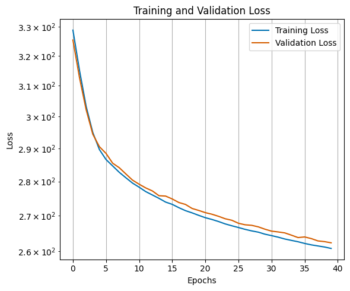

```python
# Plot training and validation loss curves
elbo = model.history['elbo_train'] # type: ignore
elbo['elbo_validation'] = model.history['elbo_validation'] # type:ignore

val_color = '#D55E00'  # Orange
train_color = '#0072B2'  # Blue

plt.figure(figsize=(6, 5))

plt.plot(elbo.index,  elbo['elbo_train'], color=train_color, linestyle='-', label='Training Loss')
plt.plot(elbo.index, elbo['elbo_validation'], color=val_color, linestyle='-', label='Validation Loss')
plt.title('Training and Validation Loss')
plt.xlabel('Epochs')
plt.ylabel('Loss')
plt.yscale('log')
plt.legend()
plt.grid(True)

plt.tight_layout()
```

## Dimensionality Reduction and Clustering

UMAP is computed on the DRVI latent space for visualization, and Leiden clustering is applied to identify distinct cell type populations.

```python
# Extract latent representation
adata.obsm['X_drvi'] = model.get_latent_representation() # type: ignore
```

```python
# Compute neighbors and UMAP on latent space
scanpy.pp.neighbors(adata, use_rep='X_drvi', metric='correlation')
scanpy.tl.umap(adata, min_dist=0.3)
```

```python
# Leiden clustering for cell type identification
scanpy.tl.leiden(adata, resolution=0.2)
```

## Batch Effect Assessment

UMAP visualizations colored by donor, time point, and cluster are examined to confirm that the latent space representation successfully integrates technical batches while preserving biological structure. Good batch correction shows mixing of donors within clusters while maintaining separation of distinct cell types.

```python
# Randomize cell order for visualization
scanpy.pp.subsample(adata, fraction=1.0)
```

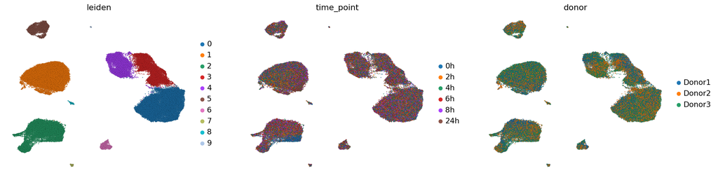

```python
# Visualize UMAP colored by cluster, time, and donor
scanpy.settings.set_figure_params(figsize=(6, 5)) # type: ignore
scanpy.pl.umap(adata, color=['leiden', 'time_point', 'donor'], size=8, alpha=0.7, edgecolor='black', linewidth=0.1, frameon=False)
```

## Cluster Characterization and Validation

Clusters are characterized by computing correlations between latent dimensions and cluster assignments. Canonical cell type markers are used to validate cluster identities, and cluster composition is examined across donors and timepoints.

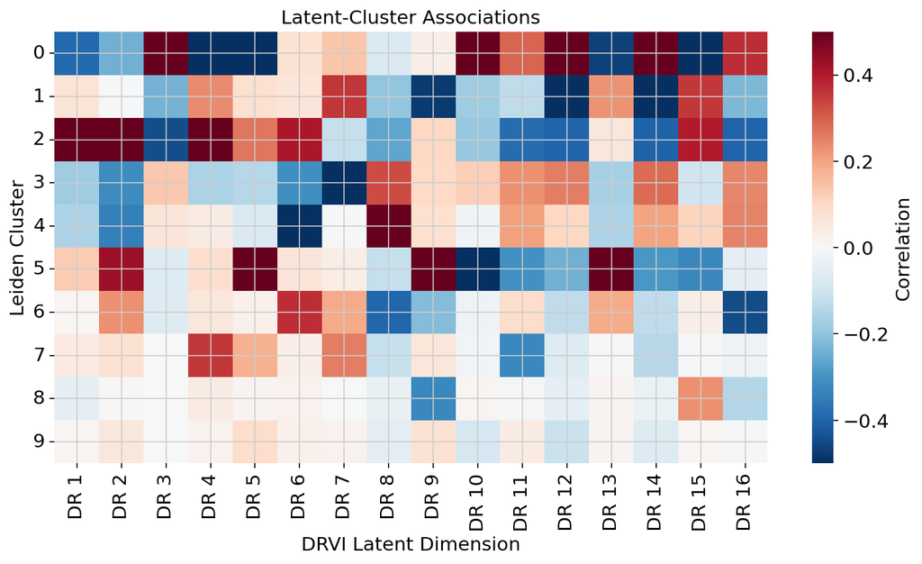

```
Top 2 latents per cluster:
Cluster 0: DR 12 (r=0.77), DR 14 (r=0.68)
Cluster 1: DR 12 (r=-0.54), DR 14 (r=-0.50)
Cluster 2: DR 1 (r=0.62), DR 2 (r=0.52)
Cluster 3: DR 7 (r=-0.72), DR 8 (r=0.33)
Cluster 4: DR 8 (r=0.66), DR 6 (r=-0.59)
Cluster 5: DR 13 (r=0.78), DR 5 (r=0.69)
Cluster 6: DR 16 (r=-0.45), DR 8 (r=-0.39)
Cluster 7: DR 4 (r=0.35), DR 11 (r=-0.32)
Cluster 8: DR 9 (r=-0.32), DR 15 (r=0.23)
Cluster 9: DR 12 (r=-0.11), DR 5 (r=0.09)
```

```python
# Compute and plot latent-cluster correlation heatmap
# Compute correlation matrix: clusters × latents
obsm_key = 'X_drvi'
cluster_key = 'leiden'

Z = numpy.asarray(adata.obsm[obsm_key])
clusters = adata.obs[cluster_key].astype(str).values
clus_names = sorted(numpy.unique(clusters)) # type: ignore

# Correlation per cluster × latent
corr_matrix = []
for c in clus_names:
    y = (clusters == c).astype(float)
    r = [numpy.corrcoef(Z[:, j], y)[0, 1] for j in range(Z.shape[1])]
    corr_matrix.append(r)

corr_df = pandas.DataFrame(corr_matrix,
                           index=clus_names,
                           columns=[f'DR {i+1}' for i in range(Z.shape[1])])

# Heatmap
plt.figure(figsize=(10, 6))
sns.heatmap(corr_df, cmap='RdBu_r', center=0, vmin=-0.5, vmax=0.5,
            cbar_kws={'label': 'Correlation'}, linewidths=0)

plt.title('Latent-Cluster Associations')
plt.xlabel('DRVI Latent Dimension')
plt.ylabel('Leiden Cluster')
plt.yticks(rotation=0)
plt.tight_layout()
plt.show()

# Show top 2 latents per cluster
print("\nTop 2 latents per cluster:")
for c in clus_names:
    top_latents = corr_df.loc[c].abs().nlargest(2) # type:ignore
    print(f"Cluster {c}: {', '.join([f'{lat} (r={corr_df.loc[c, lat]:.2f})' for lat in top_latents.index])}")
```

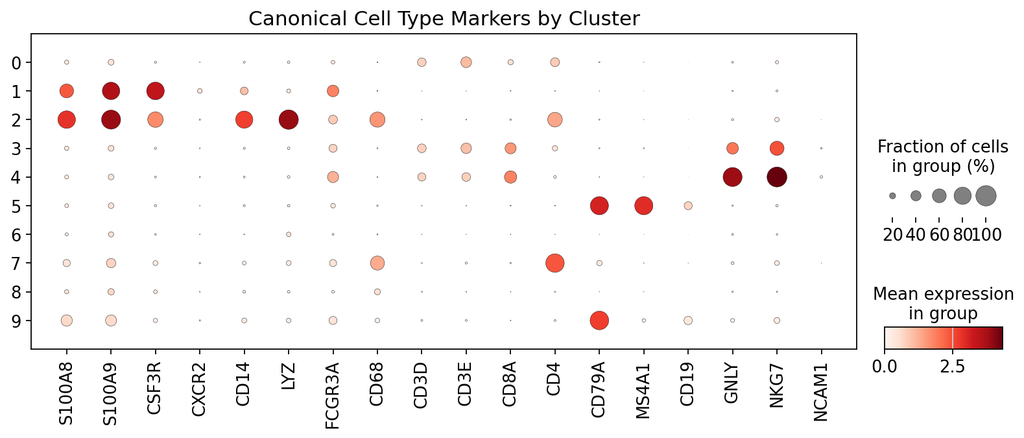

```python
# Validate clusters with canonical cell type markers
# Canonical marker genes for validation
marker_genes = {
    'Neutrophils': ['S100A8', 'S100A9', 'CSF3R', 'CXCR2'],
    'Monocytes': ['CD14', 'LYZ', 'FCGR3A', 'CD68'],
    'T cells': ['CD3D', 'CD3E', 'CD8A', 'CD4'],
    'B cells': ['CD79A', 'MS4A1', 'CD19'],
    'NK cells': ['GNLY', 'NKG7', 'NCAM1'],
}

# Flatten for dotplot
marker_genes = [gene for genes in marker_genes.values() for gene in genes if gene in adata.raw.var_names]

scanpy.pl.dotplot(adata, var_names=marker_genes, groupby='leiden',
                  title='Canonical Cell Type Markers by Cluster',
                  figsize=(12, 4), use_raw=True)
```

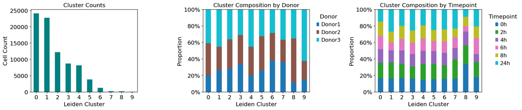

```
Total: 81,685 cells
```

```python
# Visualize cluster composition (counts, donor, timepoint)
# consistent cluster order
if adata.obs['leiden'].dtype == 'category':
    cluster_order = list(adata.obs['leiden'].cat.categories)
else:
    cluster_order = sorted(adata.obs['leiden'].unique())

# data tables
counts = adata.obs['leiden'].value_counts().reindex(cluster_order)

by_donor_prop = (pandas.crosstab(adata.obs['leiden'], adata.obs['donor'], normalize='index')
                   .reindex(cluster_order))
by_time_prop = (pandas.crosstab(adata.obs['leiden'], adata.obs['time_point'], normalize='index')
                  .reindex(cluster_order))

fig, axes = plt.subplots(1, 3, figsize=(18, 4))

# Panel A: total counts per cluster (non-stacked)
counts.plot(kind='bar', ax=axes[0], grid=False, color='teal')
axes[0].set_title('Cluster Counts')
axes[0].set_xlabel('Leiden Cluster')
axes[0].set_ylabel('Cell Count')
axes[0].tick_params(axis='x', rotation=0)

# Panel B: stacked proportions by donor
by_donor_prop.plot(kind='bar', stacked=True, ax=axes[1], grid=False, cmap='tab10')
axes[1].set_title('Cluster Composition by Donor')
axes[1].set_xlabel('Leiden Cluster')
axes[1].set_ylabel('Proportion')
axes[1].yaxis.set_major_formatter(mtick.PercentFormatter(1.0))
axes[1].set_ylim(0, 1)
axes[1].legend(title='Donor', bbox_to_anchor=(1.02, 1), loc='upper left', frameon=False)
axes[1].tick_params(axis='x', rotation=0)

# Panel C: stacked proportions by timepoint
by_time_prop.plot(kind='bar', stacked=True, ax=axes[2], grid=False, cmap='tab10')
axes[2].set_title('Cluster Composition by Timepoint')
axes[2].set_xlabel('Leiden Cluster')
axes[2].set_ylabel('Proportion')
axes[2].yaxis.set_major_formatter(mtick.PercentFormatter(1.0))
axes[2].set_ylim(0, 1)
axes[2].legend(title='Timepoint', bbox_to_anchor=(1.02, 1), loc='upper left', frameon=False)
axes[2].tick_params(axis='x', rotation=0)

plt.tight_layout()
plt.show()

print(f'\nTotal: {adata.n_obs:,} cells')
```

## Differential Expression Analysis

Wilcoxon rank-sum tests are performed to identify genes that are specifically upregulated in each cluster compared to all other cells.

```python
# Perform differential expression analysis per cluster
adata.var['symbol'] = ~adata.var_names.str.contains('ENSG', na=False)

scanpy.tl.rank_genes_groups(adata, groupby='leiden', method='wilcoxon', use_raw=False, mask_var='symbol')

deg_up = scanpy.get.rank_genes_groups_df(adata, group=None, pval_cutoff=0.01, log2fc_min=0)
# deg_up = markers.query('pvals_adj < 0.01 and logfoldchanges > 0').copy()
```

```python
# Extract top 5 upregulated genes per cluster
top_up_genes = (deg_up
        .sort_values(['group', 'logfoldchanges'], ascending=[True, False])
        .groupby('group')
        .head(5)
        .reset_index(drop=True))
```

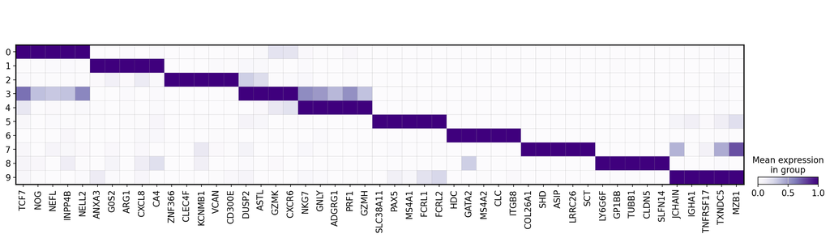

```python
# Heatmap of top cluster markers
scanpy.pl.matrixplot(
    adata,
    var_names=top_up_genes['names'].unique().tolist(),
    groupby='leiden', use_raw=True, cmap='Purples',
    standard_scale='var', dendrogram=False
)
```

```python
# Save marker gene table
top_up_genes.to_csv('/content/drive/My Drive/neutrophills_singlecell/rank_gene_group_markers.tsv', sep='\t')
```

## Cell Type Annotation and Export

Biological cell type labels are assigned to clusters based on marker gene expression patterns. The final annotated atlas is exported for downstream analysis.

```python
# Assign biological cell type labels to clusters
# cluster_labels = {
#     '0': 'CD4+ T cells (naive/Treg)',
#     '1': 'Immature neutrophils',
#     '2': 'Classical monocytes',
#     '3': 'CD8+ T cells (cytotoxic)',
#     '4': 'Natural killer (NK) cells',
#     '5': 'B cells (naive/memory)',
#     '6': 'Basophils',
#     '7': 'Ambient RNA / Low-quality',
#     '8': 'Megakaryocytes / Platelets',
#     '9': 'Plasma cells'
# }

cluster_labels = {
    '0': 'CD4 T cells',
    '1': 'Neu (imm)',
    '2': 'Monocytes',
    '3': 'CD8 T cells',
    '4': 'NK',
    '5': 'B cells',
    '6': 'Basophils',
    '7': 'AmbientRNA',
    '8': 'Mk/Plt',
    '9': 'Plasma cells'
}


# assign the cell type to obs
adata.obs['cell_type'] = adata.obs['leiden'].map(cluster_labels).astype('category')

# check
adata.obs['cell_type'].value_counts()
```

| cell_type | count |
| --- | --- |
| CD4 T cells | 24121 |
| Neu (imm) | 22774 |
| Monocytes | 12214 |
| CD8 T cells | 8736 |
| NK | 8177 |
| B cells | 3875 |
| Basophils | 1250 |
| AmbientRNA | 264 |
| Mk/Plt | 202 |
| Plasma cells | 72 |

**dtype:** int64

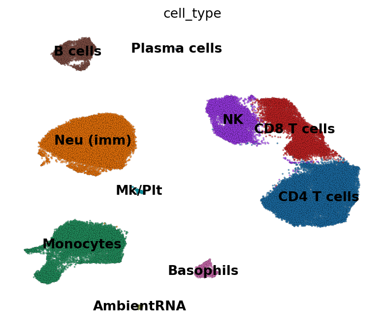

```python
# Visualize annotated UMAP with cell type labels
scanpy.settings.set_figure_params(figsize=(6, 5), fontsize=12)  # type: ignore
scanpy.pl.umap(adata, color='cell_type', size=8, alpha=0.7, edgecolor='black', linewidth=0.1, frameon=False, legend_loc='on data')
```

```python
# Save final annotated atlas
adata.write_h5ad('/content/drive/My Drive/neutrophills_singlecell/all_celltypes.h5ad') # type: ignore
```

```python
# Extract metadata subset
cols = ['leiden', 'cell_type']

metadata = adata.obs[cols].copy()
metadata.index.name = 'barcode'
```

```python
# Export metadata table
metadata.to_csv('/content/drive/My Drive/neutrophills_singlecell/atlas_metadata.tsv', sep='\t')
```